# Assignment 2

Angelah Kgato Gaolatlhe

2026-01-22

# Question 1

View the data for each of the 4 regression functions f1, … , f4 .

```r
library(KernSmooth)
```

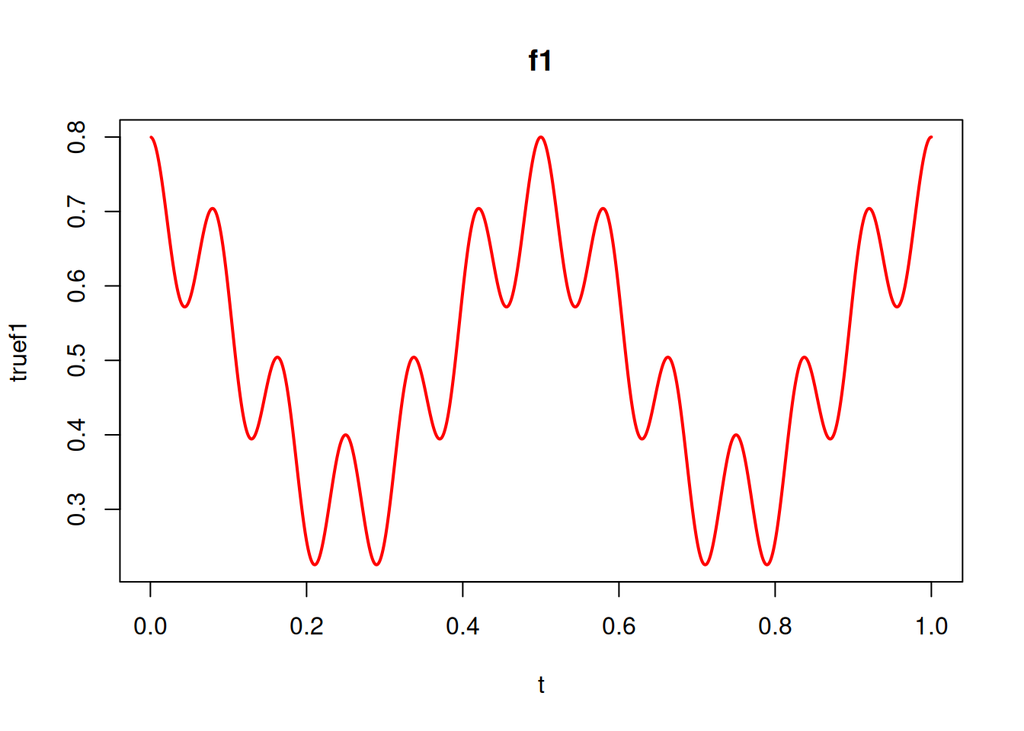

```r
# Configuration
T <- 1000
t <- (1:T)/T

n <- 100
x <- (1:n)/n
rsnr <- 5

# Define the 4 true functions
truef1 <- 0.5 + (0.2*cos(4*pi*t)) + (0.1*cos(24*pi*t))
truef2 <- 0.2 + 0.6*(t > 1/3 & t <= 0.75)
truef3 <- 4*sin(4*pi*t) - sign(t - 0.3) - sign(0.72 - t) + 5
truef4 <- sqrt(t*(1 - t)) * sin((2*pi*1.05)/(t + 0.05)) + 0.5

plot(t,truef1,type="l",col="red",lwd=2,main="f1")
```

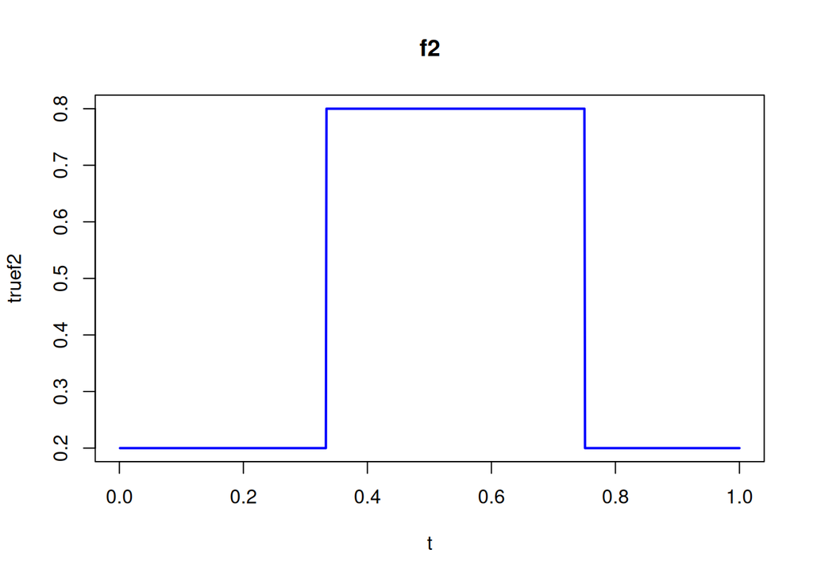

```r
plot(t,truef2,type="l",col="blue",lwd=2,main="f2")
```

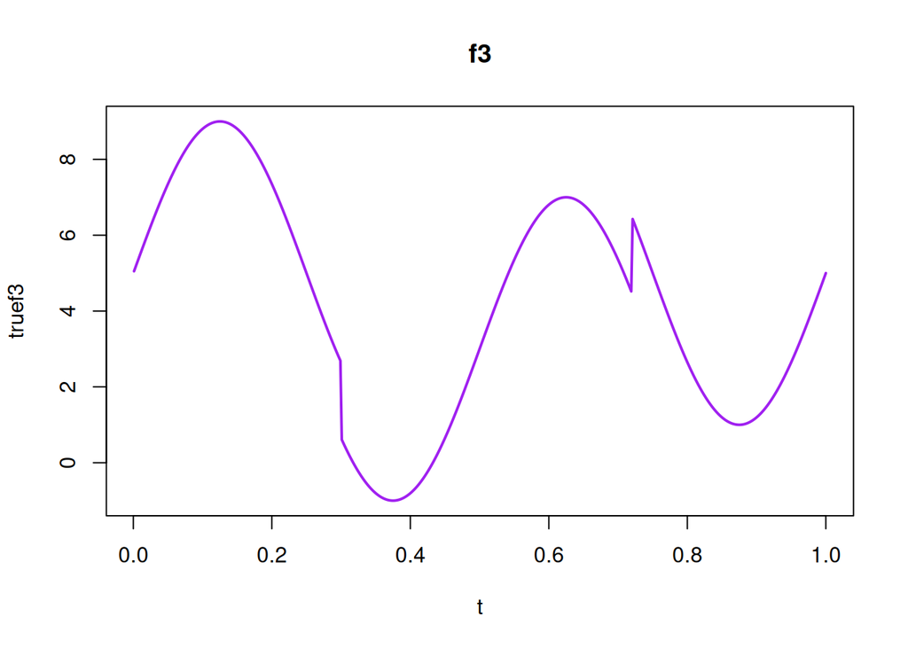

```r
plot(t,truef3,type="l",col="purple",lwd=2,main="f3")
```

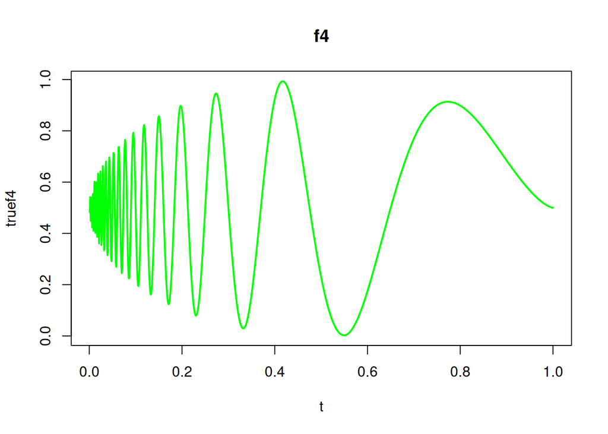

```r
plot(t,truef4,type="l",col="green",lwd=2,main="f4")
```

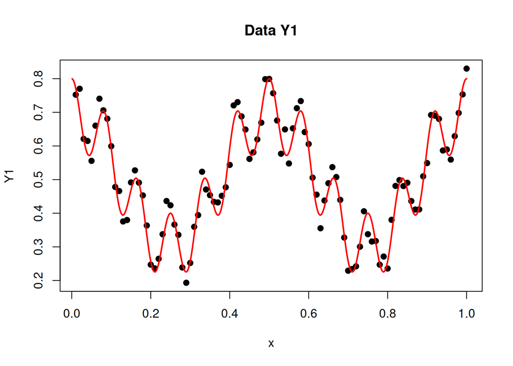

```r
# Generate Y observations for f1
f1 <- 0.5 + (0.2*cos(4*pi*x)) + (0.1*cos(24*pi*x))
sigma1 <- sd(f1)/rsnr
Y1 <- f1 + rnorm(n, mean=0, sd=sigma1)
plot(x,Y1,pch=19,main="Data Y1"); lines(t,truef1,col="red",lwd=2)
```

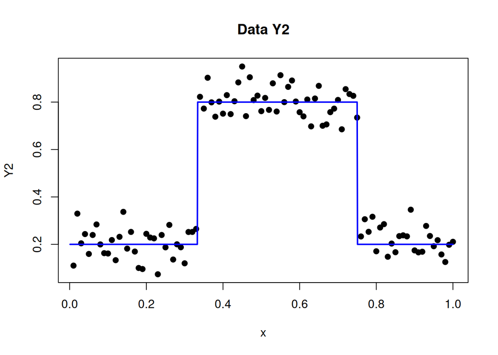

```r
# Generate Y observations for f2
f2 <- 0.2 + 0.6*(x > 1/3 & x <= 0.75)
sigma2 <- sd(f2)/rsnr
Y2 <- f2 + rnorm(n, mean=0, sd=sigma2)
plot(x,Y2,pch=19,main="Data Y2"); lines(t,truef2,col="blue",lwd=2)
```

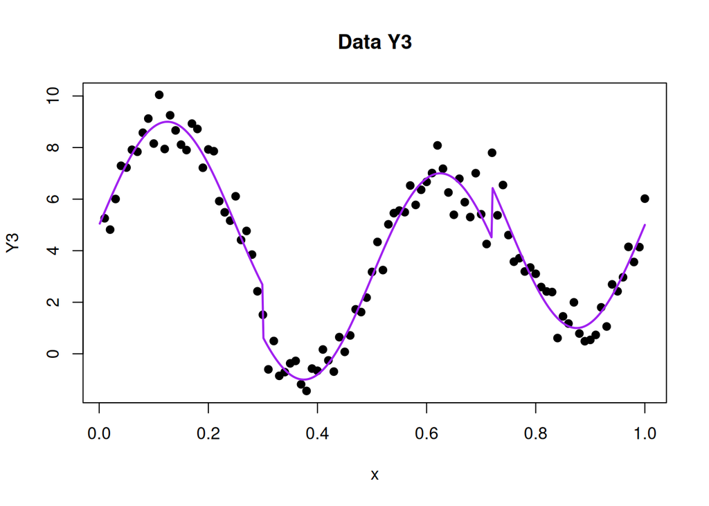

```r
# Generate Y observations for f2
f3 <- 4*sin(4*pi*x) - sign(x - .3) - sign(.72 - x) + 5
sigma3 <- sd(f3)/rsnr
Y3 <- f3 + rnorm(n, mean=0, sd=sigma3)
plot(x,Y3,pch=19,main="Data Y3"); lines(t,truef3,col="purple",lwd=2)
```

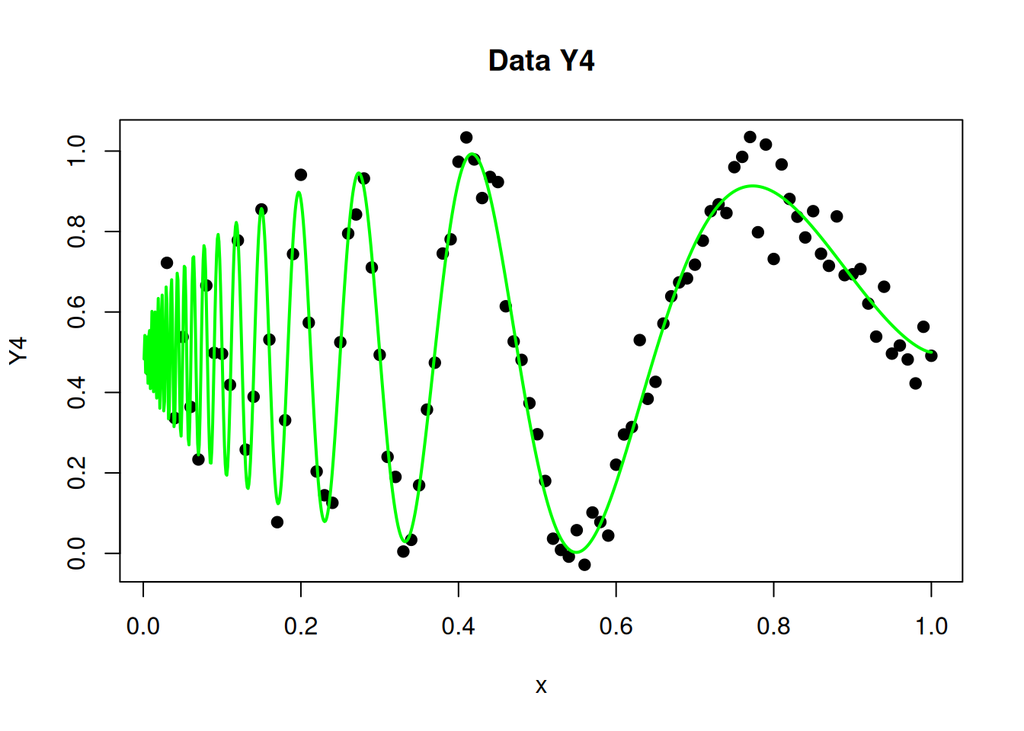

```r
# Generate Y observations for f2
f4 <- sqrt(x*(1-x))*sin((2*pi*1.05)/(x+.05)) + 0.5
sigma4 <- sd(f4)/rsnr
Y4 <- f4 + rnorm(n, mean=0, sd=sigma4)
plot(x,Y4,pch=19,main="Data Y4"); lines(t,truef4,col="green",lwd=2)
```

From the above plots, $f_1$ is smooth and periodic, $f_2$ is piece-wise constant with very abrupt jumps, $f_3$ is a mixture of oscillations and discontinuities and $f_4$ is an oscillatory function.

# Question 2

Fit a kernel estimator for each of the 4 data sets Y1 , . . . , Y4 which correspond to the functions f1 , . . . , f4 .

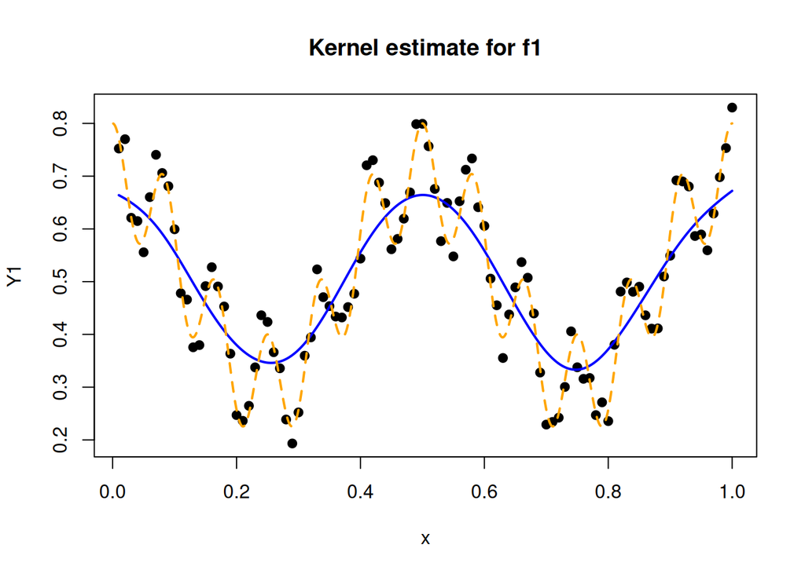

```r
fit1 <- locpoly(x, Y1, bandwidth = 0.05, degree = 0)
plot(x, Y1, pch=19, col="black", main="Kernel estimate for f1")
lines(fit1, col="blue", lwd=2)
lines(t, truef1, col="orange", lwd=2, lty=2)
```

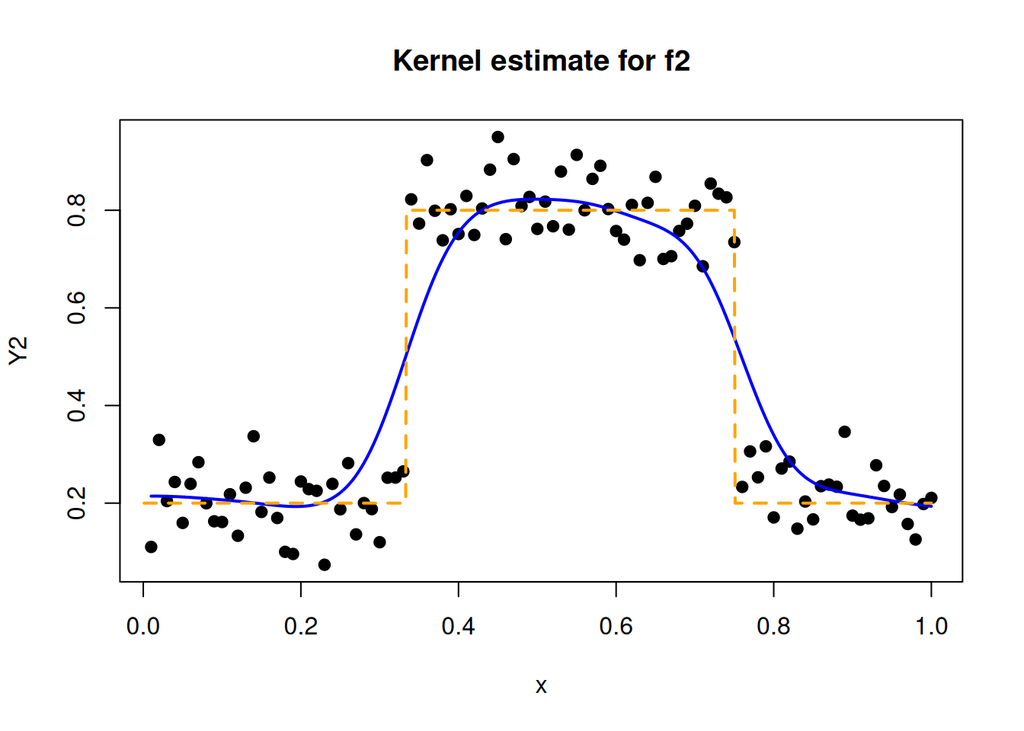

```r
fit2 <- locpoly(x, Y2, bandwidth = 0.05, degree = 0)
plot(x, Y2, pch=19, col="black", main="Kernel estimate for f2")
lines(fit2, col="blue", lwd=2)
lines(t, truef2, col="orange", lwd=2, lty=2)
```

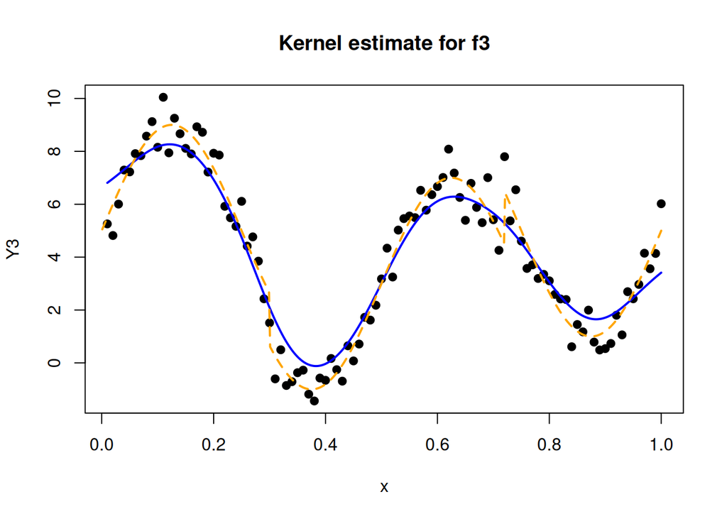

```r
fit3 <- locpoly(x, Y3, bandwidth = 0.05, degree = 0)
plot(x, Y3, pch=19, col="black", main="Kernel estimate for f3")
lines(fit3, col="blue", lwd=2)
lines(t, truef3, col="orange", lwd=2, lty=2)
```

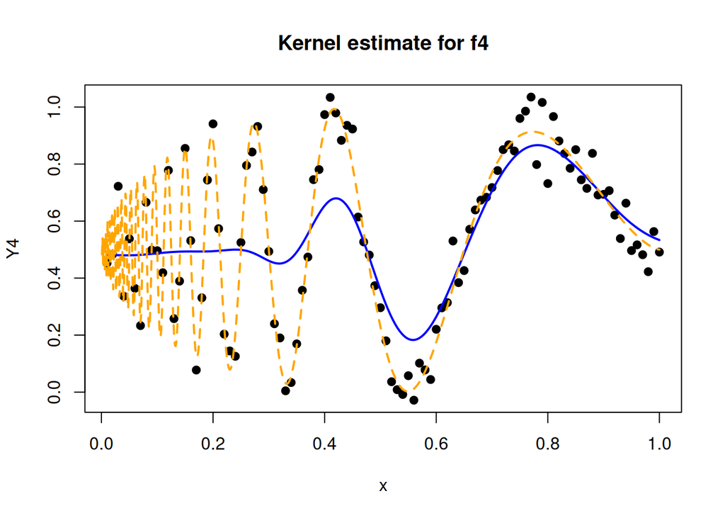

```r
fit4 <- locpoly(x, Y4, bandwidth = 0.05, degree = 0)
plot(x, Y4, pch=19, col="black", main="Kernel estimate for f4")
lines(fit4, col="blue", lwd=2)
lines(t, truef4, col="orange", lwd=2, lty=2)
```